# DATA ANALYSIS OF THE RARE SOAY SHEEP

2024-01-10

## The problem

The NAO’s mean strength affects the survival of the rare soay sheep, potentially explained by weight changes. This study explores the impact of NAO and other variables on sheep weight and from the question it was evident that weight of the sheep is the response variable

## Loading the data into Rstudio and modifiying based on requirements:

Both the tsv files were loaded by read.tsv function using readr package to the respective data frames.

describe() used to describe the data and year was found common in both files and the rest of the columns were altered accordingly to remove the missing values and sex data was altered to female with value 0 and male with value 1 for easy analysis.

A new column of just mean summer NAO and mean NAO of 12 months was created ,grouped by year and merged with the sheep_data to form a new dataframe merged_sheep_data

```r
#here we are using merge.data.frame to merge the mean data with respect to years to plot the further data
merged_sheep_data <-  merge.data.frame(sNAO,na_drop_Sgroup, by= "year",all= TRUE) %>%
  merge.data.frame(mNAO,by="year",all=TRUE)%>%
  merge.data.frame(mweight,by="year",all=TRUE)
Hmisc::describe(merged_sheep_data)
```

```
## merged_sheep_data
##
##  11  Variables      2785  Observations
## --------------------------------------------------------------------------------
## year
##        n  missing distinct     Info     Mean      Gmd      .05      .10
##     2785        0       41    0.999     2003    12.42     1985     1988
##      .25      .50      .75      .90      .95
##     1995     2004     2013     2017     2019
##
## lowest : 1980 1981 1982 1983 1984, highest: 2016 2017 2018 2019 2020
## --------------------------------------------------------------------------------
## mean_sNAO
##        n  missing distinct     Info     Mean      Gmd      .05      .10
##     2785        0       41    0.999   0.5509   0.3213  0.08549  0.16908
##      .25      .50      .75      .90      .95
##  0.30765  0.61704  0.77956  0.90171  0.95680
##
## lowest : -0.0648833 0.0115419  0.0206715  0.0526193  0.0612367
## highest: 0.901099   0.90171    0.913856   0.956795   0.981408
## --------------------------------------------------------------------------------
## ID
##        n  missing distinct     Info     Mean      Gmd      .05      .10
##     2785        0      404        1    202.4    133.9       23       45
##      .25      .50      .75      .90      .95
##      106      196      305      365      386
##
## lowest :   1   2   3   4   5, highest: 404 405 406 407 408
## --------------------------------------------------------------------------------
## age
##        n  missing distinct     Info     Mean      Gmd      .05      .10
##     2785        0       17    0.991    4.639    4.246        0        0
##      .25      .50      .75      .90      .95
##        1        4        7       10       12
##
## Value          0     1     2     3     4     5     6     7     8     9    10
## Frequency    364   342   320   281   248   229   196   169   144   128   102
## Proportion 0.131 0.123 0.115 0.101 0.089 0.082 0.070 0.061 0.052 0.046 0.037
##
## Value         11    12    13    14    15    16
```

[output cut: 52 more lines]

```
##      .25      .50      .75      .90      .95
##   0.8260   0.8952   0.9482   0.9822   1.0015
##
## lowest : 0.726319 0.757869 0.760697 0.760749 0.762897
## highest: 0.970131 0.982225 0.998779 1.00148  1.0242
## --------------------------------------------------------------------------------
## mean_weight
##        n  missing distinct     Info     Mean      Gmd      .05      .10
##     2785        0       41    0.999    7.526   0.6058    6.462    6.716
##      .25      .50      .75      .90      .95
##    7.310    7.738    7.926    8.098    8.204
##
## lowest : 5.1225  5.41357 5.87147 6.02741 6.46188
## highest: 8.09648 8.09789 8.19027 8.20433 8.26471
## --------------------------------------------------------------------------------
```

```r
experi <- filter(merged_sheep_data, age == 15) %>% dplyr::select(weight) %>% unlist

average <- mean(experi)
average
```

```
## [1] 12.53136
```

```r
experi1 <- filter(merged_sheep_data, age == 16) %>% dplyr::select(weight)%>% unlist

average1 <- mean(experi1)
average1
```

```
## [1] 13.21182
```

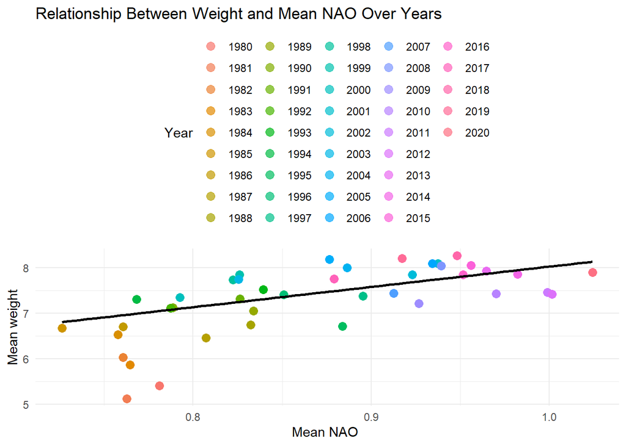

```r
# Load necessary libraries
library(dplyr)
library(ggplot2)


# Plot weight against mean NAO, grouped by year and subject ID
ggplot(merged_sheep_data, aes(x = mean_NAO, y = mean_weight, color = as.factor(year))) +
  geom_point(size = 3, alpha = 0.7) +   # Scatter plot for each subject
  geom_smooth(method = "lm", se = FALSE, color = "black") +  # Add trendline
  labs(
    title = "Relationship Between Weight and Mean NAO Over Years",
    x = "Mean NAO ",
    y = "Mean weight",
    color = "Year"
  ) +
  theme_minimal() +
  theme(legend.position = "top")
```

we can see a slight slope increase trend in Meanweight in relation with MeanNAO over the years

NAO might explain some variations in weight, but it may not a strong predictor on its own, as implied by the spread of points around the line.

## Visualization:

To further understand relation of NAO, i have plotted both meanNAO and meanNAO of the summer data against year

Trend of mean_sNAO and mean_NAO over the years

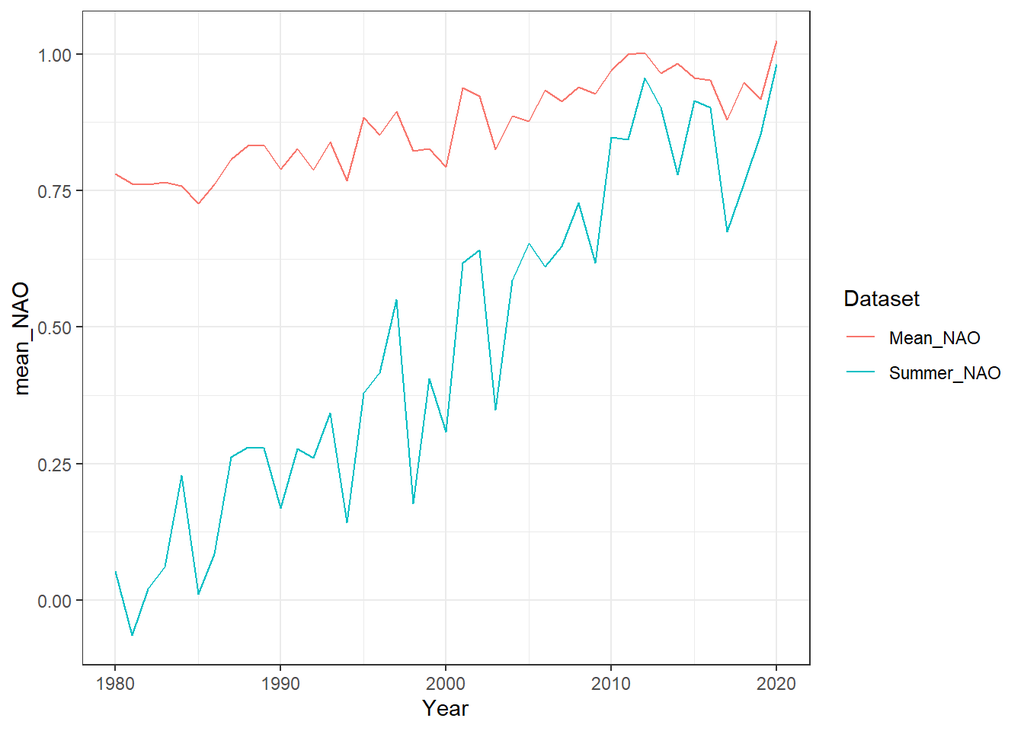

```r
#plot the mean_NAO throughout the years to check the patterns
ggplot() +
    # Add a line for the 'mean_NAO' variable from the merged_sheep_data dataset
  geom_line(data = merged_sheep_data, aes(x = year, y = mean_NAO, color = "Mean_NAO")) +
    # Add another line for the 'mean_sNAO' variable from the merged_sheep_data dataset
  geom_line(data = merged_sheep_data, aes(x = year, y = mean_sNAO, color = "Summer_NAO")) +
  labs(x = "Year", y = "mean_NAO", color = "Dataset") +
  theme_bw()
```

```r
# Save the plot to your computer
#ggsave("C:/Users/jayas/OneDrive/Pictures/mean_NAO_trend.jpg", plot = p1, device = "jpg")
```

Graph shows an upward trend in both Mean NAO (red) and Summer NAO (blue) from the 1980s to 2020.

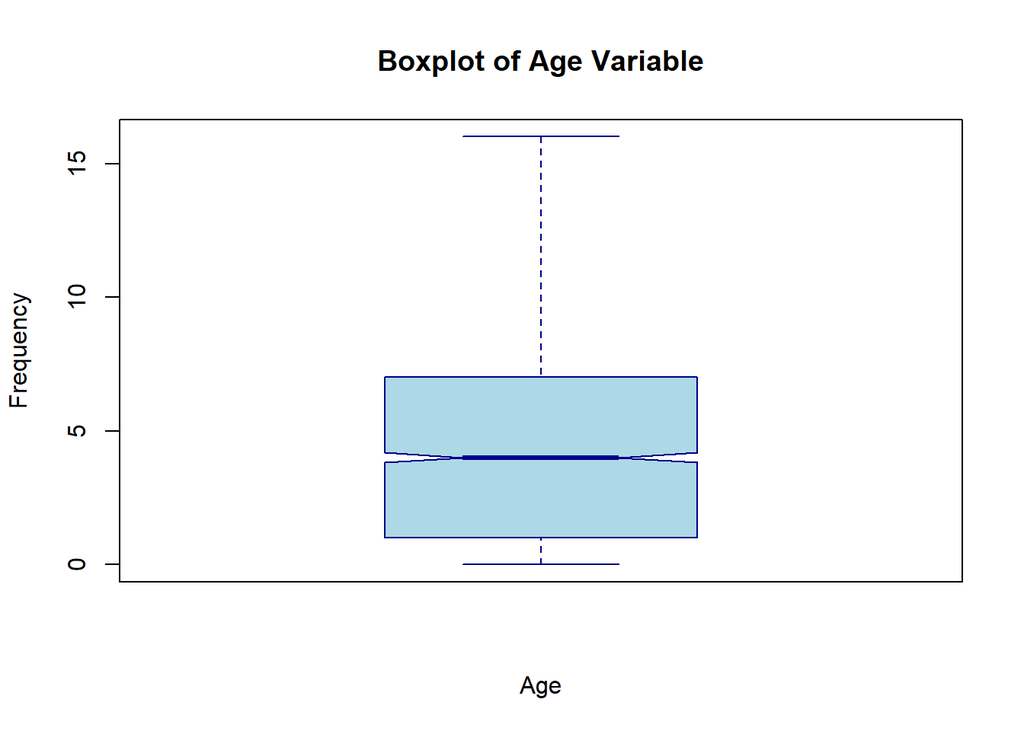

```r
# Create a boxplot for the 'age' variable with customized colors and axis label
boxplot_age <- boxplot(
  merged_sheep_data$age,
  outline = TRUE,
  col = "lightblue", # Box color
  border = "darkblue", # Border color
  main = "Boxplot of Age Variable", # Title of the boxplot
  xlab = "Age", # X-axis label
  ylab = "Frequency", # Y-axis label
  notch = TRUE # Add notches for better visualization
)
```

```r
# Extract the outliers from the boxplot
outliers_age <- boxplot_age$out

# Sort the outliers in ascending order
sorted_outliers_age <- sort(outliers_age)

# Display the sorted outliers
sorted_outliers_age
```

```
## numeric(0)
```

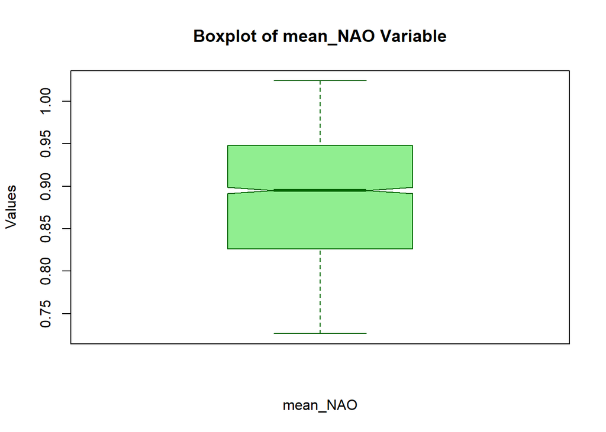

```r
# Create a boxplot for the 'mean_NAO' variable with customizations
boxplot_mean_NAO <- boxplot(
  merged_sheep_data$mean_NAO,
  outline = TRUE,
  col = "lightgreen", # Box color
  border = "darkgreen", # Border color
  main = "Boxplot of mean_NAO Variable", # Title of the boxplot
  xlab = "mean_NAO", # X-axis label
  ylab = "Values", # Y-axis label
  notch = TRUE # Add notches for better visualization
)
```

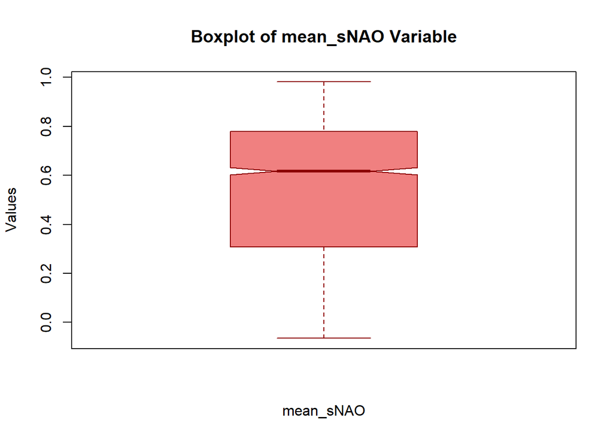

```r
# Extract and sort outliers
outliers_mean_NAO <- boxplot_mean_NAO$out
sorted_outliers_mean_NAO <- sort(outliers_mean_NAO)

# Create a boxplot for the 'mean_sNAO' variable with customizations
boxplot_mean_sNAO <- boxplot(
  merged_sheep_data$mean_sNAO,
  outline = TRUE,
  col = "lightcoral", # Box color
  border = "darkred", # Border color
  main = "Boxplot of mean_sNAO Variable", # Title of the boxplot
  xlab = "mean_sNAO", # X-axis label
  ylab = "Values", # Y-axis label
  notch = TRUE # Add notches for better visualization
)
```

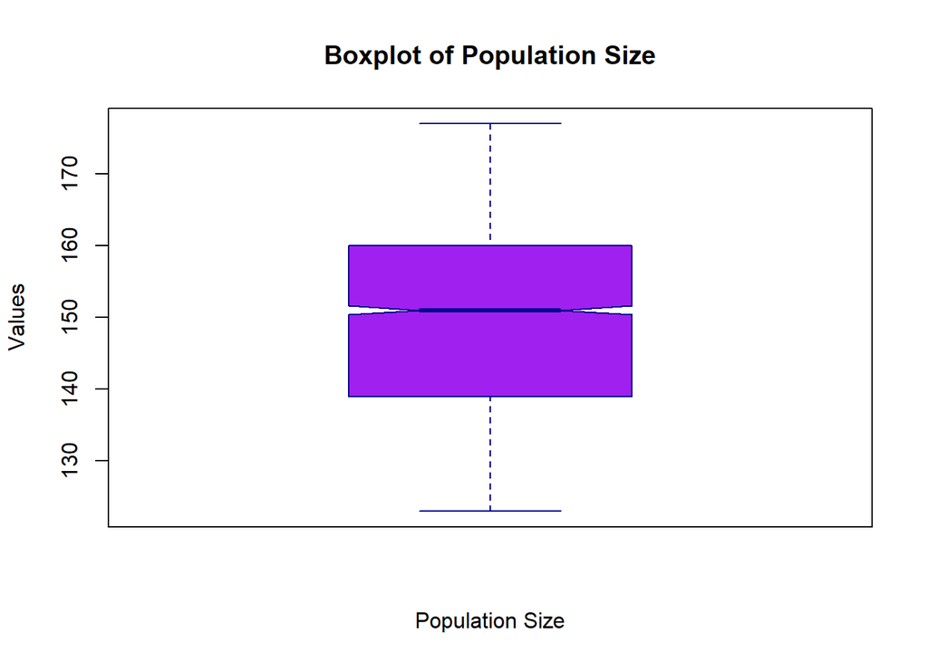

```r
# Extract and sort outliers
outliers_mean_sNAO <- boxplot_mean_sNAO$out
sorted_outliers_mean_sNAO <- sort(outliers_mean_sNAO)

# Create a boxplot for the 'pop_size' variable with customizations
boxplot_pop_size <- boxplot(
  merged_sheep_data$pop_size,
  outline = TRUE,
  col = "purple", # Box color
  border = "darkblue", # Border color
  main = "Boxplot of Population Size", # Title of the boxplot
  xlab = "Population Size", # X-axis label
  ylab = "Values", # Y-axis label
  notch = TRUE # Add notches for better visualization
)
```

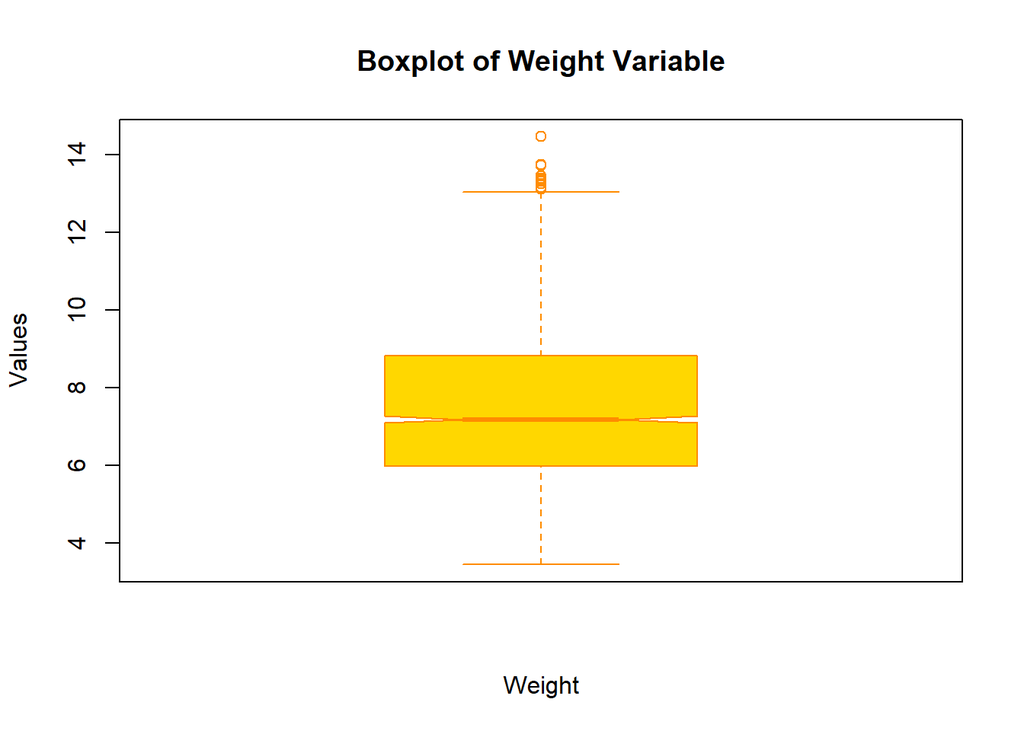

```r
# Extract and sort outliers
outliers_pop_size <- boxplot_pop_size$out
sorted_outliers_pop_size <- sort(outliers_pop_size)

# Create a boxplot for the 'weight' variable with customizations
boxplot_weight <- boxplot(
  merged_sheep_data$weight,
  outline = TRUE,
  col = "gold", # Box color
  border = "darkorange", # Border color
  main = "Boxplot of Weight Variable", # Title of the boxplot
  xlab = "Weight", # X-axis label
  ylab = "Values", # Y-axis label
  notch = TRUE # Add notches for better visualization
)
```

```r
# Extract and sort outliers
outliers_weight <- boxplot_weight$out
sorted_outliers_weight <- sort(outliers_weight)
```

The Box plot of graph Age, mean_NAO, mean_SNAO, population size, weight represents that only weight variable have outliears, now to further check the outliears points in graph

```r
# Print the sorted outliers
print(sorted_outliers_age)
```

```
## numeric(0)
```

```r
print(sorted_outliers_mean_NAO)
```

```
## numeric(0)
```

```r
print(sorted_outliers_mean_sNAO)
```

```
## numeric(0)
```

```r
print(sorted_outliers_pop_size)
```

```
## numeric(0)
```

```r
print(sorted_outliers_weight)
```

```
##  [1] 13.11 13.14 13.16 13.25 13.26 13.31 13.33 13.35 13.36 13.36 13.38 13.38
## [13] 13.44 13.73 13.73 13.74 14.46
```

```r
# Extract rows where 'weight' corresponds to the outlier values
outlier_data <- merged_sheep_data %>% filter(weight %in% sorted_outliers_weight)

# View the corresponding ages for the outliers
print(outlier_data %>% dplyr::select(weight, age))
```

```
##    weight age
## 1   13.14  15
## 2   13.11  16
## 3   13.26  15
## 4   13.25  16
## 5   13.16  15
## 6   13.36  13
## 7   13.38  15
## 8   13.73  16
## 9   13.38  15
## 10  14.46  16
## 11  13.33  15
## 12  13.73  16
## 13  13.31  15
## 14  13.44  15
## 15  13.36  15
## 16  13.35  16
## 17  13.74  16
```

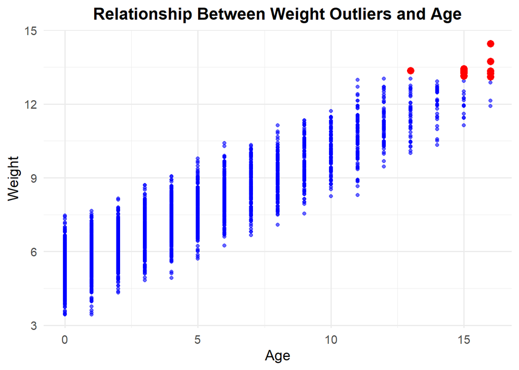

```r
# Plot to visualize if outliers in weight are related to age
ggplot(merged_sheep_data, aes(x = age, y = weight)) +
  geom_point(color = "blue", alpha = 0.6) +  # Plot all data points
  geom_point(data = outlier_data, aes(x = age, y = weight), color = "red", size = 3) + # Highlight outliers
  labs(
    title = "Relationship Between Weight Outliers and Age",
    x = "Age",
    y = "Weight"
  ) +
  theme_minimal(base_size = 14) +
  theme(
    plot.title = element_text(face = "bold", size = 16, hjust = 0.5)
  )
```

```r
# Ensure dplyr and ggplot2 libraries are loaded
library(dplyr)
library(ggplot2)

# Extract rows where 'weight' corresponds to outlier values, including 'ID' and 'age'
outlier_data <- merged_sheep_data %>%
  filter(weight %in% sorted_outliers_weight) %>%
  dplyr::select(ID, weight, age)
# View the filtered data
print(outlier_data)
```

```
##     ID weight age
## 1  268  13.14  15
## 2   89  13.11  16
## 3  396  13.26  15
## 4  343  13.25  16
## 5  173  13.16  15
## 6  183  13.36  13
## 7  101  13.38  15
## 8  101  13.73  16
## 9  183  13.38  15
## 10 183  14.46  16
## 11  48  13.33  15
## 12  48  13.73  16
## 13 179  13.31  15
## 14  95  13.44  15
## 15 142  13.36  15
## 16 179  13.35  16
## 17 142  13.74  16
```

```r
# Ensure dplyr is loaded
library(dplyr)

# Group the outlier data by 'ID' and summarize
outliers_by_ID <- outlier_data %>%
  group_by(ID) %>%  # Group by ID
  summarise(
    count = n(),                # Count of outliers per ID
    min_age = min(age, na.rm = TRUE),  # Minimum age when outlier occurred
    max_age = max(age, na.rm = TRUE),  # Maximum age when outlier occurred
    avg_weight = mean(weight, na.rm = TRUE)  # Average weight of outliers
  )

# View summarized outlier data by ID
print(outliers_by_ID)
```

```
## # A tibble: 11 × 5
##       ID count min_age max_age avg_weight
##    <dbl> <int>   <dbl>   <dbl>      <dbl>
##  1    48     2      15      16       13.5
##  2    89     1      16      16       13.1
##  3    95     1      15      15       13.4
##  4   101     2      15      16       13.6
##  5   142     2      15      16       13.6
##  6   173     1      15      15       13.2
##  7   179     2      15      16       13.3
##  8   183     3      13      16       13.7
##  9   268     1      15      15       13.1
## 10   343     1      16      16       13.2
## 11   396     1      15      15       13.3
```

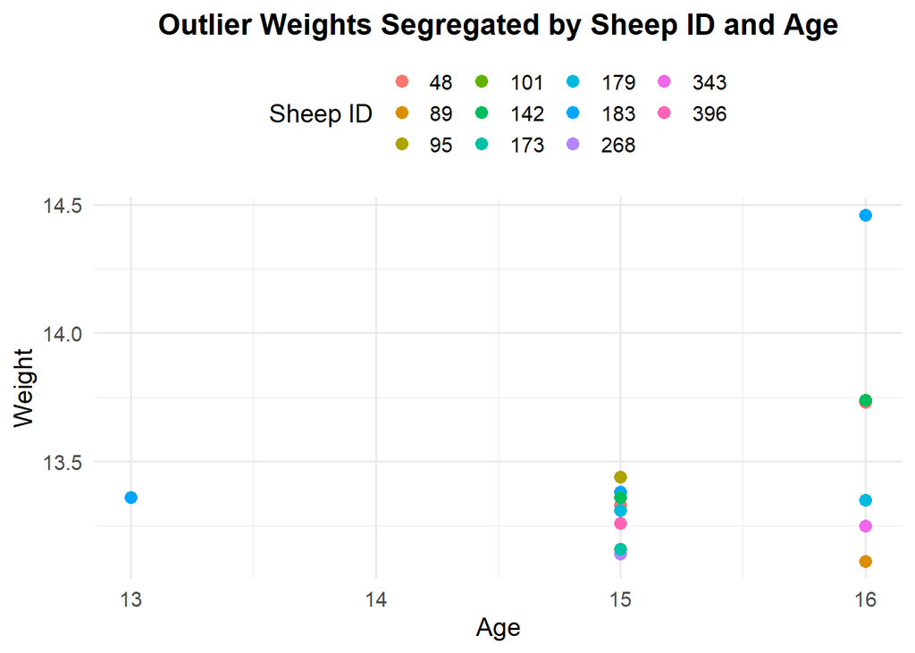

```r
# Plot outlier weights over age for each ID
ggplot(outlier_data, aes(x = age, y = weight, color = as.factor(ID))) +
  geom_point(size = 3) +  # Highlight outliers
  labs(
    title = "Outlier Weights Segregated by Sheep ID and Age",
    x = "Age",
    y = "Weight",
    color = "Sheep ID"
  ) +
  theme_minimal(base_size = 14) +
  theme(
    legend.position = "top",
    plot.title = element_text(face = "bold", size = 16, hjust = 0.5)
  )
```

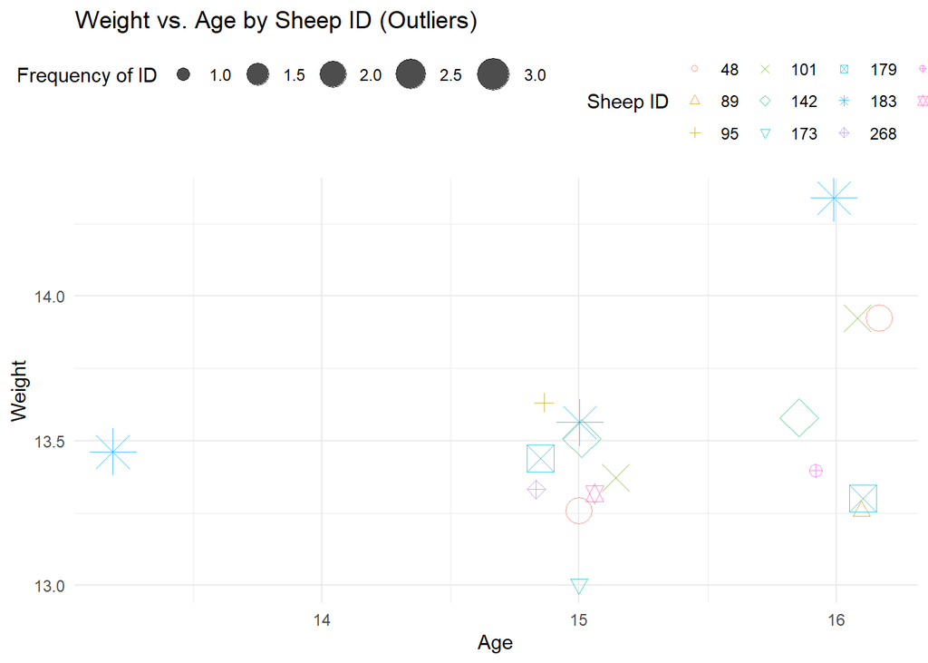

```r
library(ggplot2)

# Add a count column to represent the number of occurrences of each ID
outlier_data <- outlier_data %>%
  group_by(ID) %>%
  mutate(ID_count = n())  # Create a column that counts the number of occurrences of each ID

# Scatter plot with jitter and varying point size and shape based on ID
ggplot(outlier_data, aes(x = age, y = weight, color = as.factor(ID), size = ID_count, shape = as.factor(ID))) +
  geom_jitter(width = 0.2, height = 0.2, alpha = 0.7) +  # Jitter to avoid overlap
  labs(
    title = "Weight vs. Age by Sheep ID (Outliers)",
    x = "Age",
    y = "Weight",
    color = "Sheep ID",
    size = "Frequency of ID",
    shape = "Sheep ID"
  ) +
  theme_minimal() +
  theme(legend.position = "top") +
  scale_size_continuous(range = c(3, 8)) +  # Adjust the range for point size
  scale_shape_manual(values = 1:length(unique(outlier_data$ID)))  # Assign distinct shapes for each ID
```

only weight has outliers, which can be visible through the boxplot, to further check if the outliers are data entry error or effect of other variables, i tried plotting the weight against age to check it and it seems that as the the age of few sheeps’ reaches 15-16 there seems to be increase in weight in some sheeps.As this data cannot be traced back and graph illustrates that the weight may not be entry error , thus now we can further conduct distribution of the response variable

## Identyfying the potential error Distribution of response variable

```r
#null hypothesis : there is no affect of summer NAO on the mean body mass of the sheep

#error distribution

#checking for NaN values
merged_sheep_data <- merged_sheep_data[!is.nan(merged_sheep_data$weight), ]

#fit the response variable to normal distribution
fit_gau <- fitdist(merged_sheep_data$weight,
                   distr = "norm",)
```

for normal

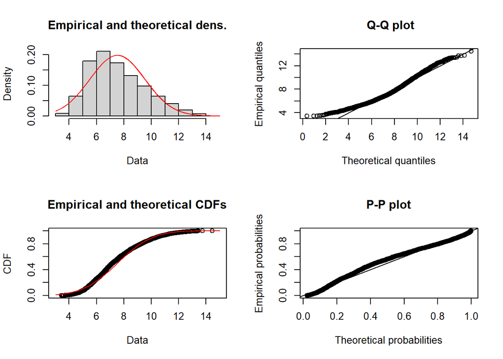

[output not shown]

The normal distribution does not seem to fit the reponse variable

```r
#fit the response variable to log normal distribution
fit_log <- fitdist(merged_sheep_data$weight,
                   dist="lnorm")
```

for lognormal

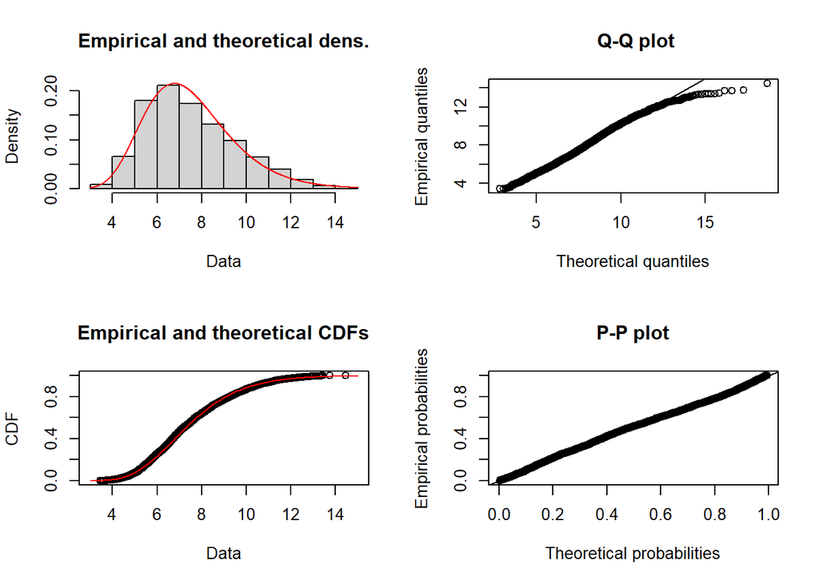

```r
#plot it
plot(fit_log)
```

```r
#summary of the distribution
gofstat(fit_log)
```

```
## Goodness-of-fit statistics
##                              1-mle-lnorm
## Kolmogorov-Smirnov statistic  0.02399734
## Cramer-von Mises statistic    0.52765077
## Anderson-Darling statistic    3.45380967
##
## Goodness-of-fit criteria
##                                1-mle-lnorm
## Akaike's Information Criterion    11547.54
## Bayesian Information Criterion    11559.41
```

The log normal distribution does not seem to fit the response variable but the stat values are better than normal distribution

```r
#fit the response variable to gamma distribution
fit_gamma <- fitdist(merged_sheep_data$weight,
                     dist="gamma")
```

for Gamma

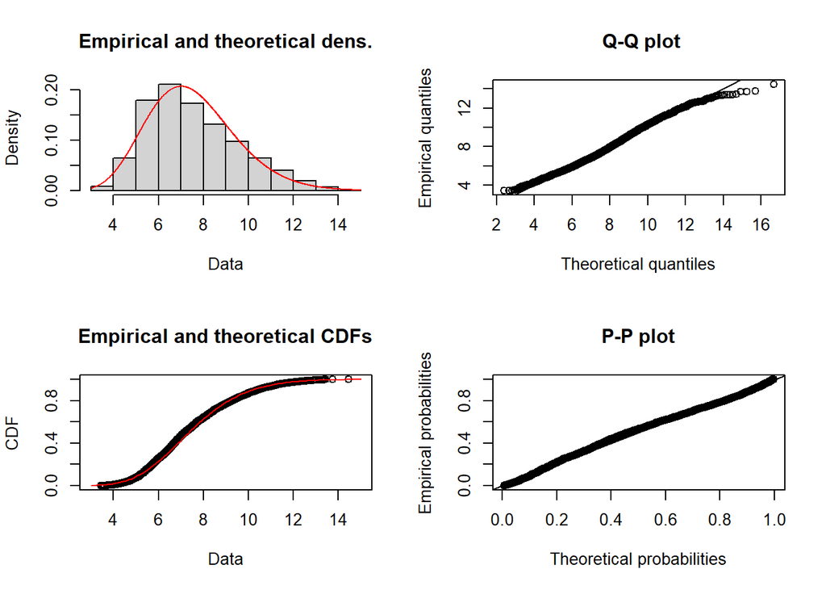

```r
#plot it
plot(fit_gamma)
```

```r
#summary of the distribution
gofstat(fit_gamma)
```

```
## Goodness-of-fit statistics
##                              1-mle-gamma
## Kolmogorov-Smirnov statistic  0.03965734
## Cramer-von Mises statistic    1.20120327
## Anderson-Darling statistic    7.23557108
##
## Goodness-of-fit criteria
##                                1-mle-gamma
## Akaike's Information Criterion    11578.79
## Bayesian Information Criterion    11590.66
```

Response variable follows log normal error distribution

Response variable has been transformed to get better error distribution

```r
#data transformation of response variable by log function
data_transformed <-   merged_sheep_data %>%
  group_by(year)%>%
  mutate(log_weight=log(weight))

#using the previous worked dataframe to add log response variable
alternative <-data_transformed %>%
  group_by(year)%>%
  mutate(mean_log_weight=mean(log_weight))
```

```r
#fit the transformed response variable to normal distribution
fit_gau1 <- fitdist(data_transformed$log_weight,
                   distr = "norm")
```

for normal

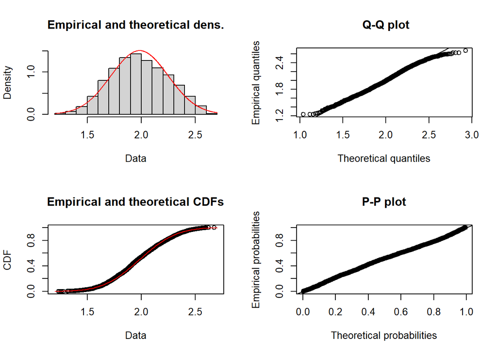

```r
#plot it
plot(fit_gau1)
```

```r
#summary of the distribution
gofstat(fit_gau1)
```

```
## Goodness-of-fit statistics
##                              1-mle-norm
## Kolmogorov-Smirnov statistic 0.02399734
## Cramer-von Mises statistic   0.52765077
## Anderson-Darling statistic   3.45380967
##
## Goodness-of-fit criteria
##                                1-mle-norm
## Akaike's Information Criterion   500.1265
## Bayesian Information Criterion   511.9905
```

```r
#from the summary we can tell that data fit the norm distribution
summary(fit_gau1)
```

```
## Fitting of the distribution ' norm ' by maximum likelihood
## Parameters :
##       estimate  Std. Error
## mean 1.9833779 0.005012257
## sd   0.2645123 0.003543973
## Loglikelihood:  -248.0633   AIC:  500.1265   BIC:  511.9905
## Correlation matrix:
##               mean            sd
## mean  1.000000e+00 -6.310794e-14
## sd   -6.310794e-14  1.000000e+00
```

for log normal

```r
#fit the transformed response variable to log normal distribution
fit_log2 <- fitdist(data_transformed$log_weight,
                   distr = "lnorm")

describe(data_transformed)
```

```
## data_transformed
##
##  12  Variables      2785  Observations
## --------------------------------------------------------------------------------
## year
##        n  missing distinct     Info     Mean      Gmd      .05      .10
##     2785        0       41    0.999     2003    12.42     1985     1988
##      .25      .50      .75      .90      .95
##     1995     2004     2013     2017     2019
##
## lowest : 1980 1981 1982 1983 1984, highest: 2016 2017 2018 2019 2020
## --------------------------------------------------------------------------------
## mean_sNAO
##        n  missing distinct     Info     Mean      Gmd      .05      .10
##     2785        0       41    0.999   0.5509   0.3213  0.08549  0.16908
##      .25      .50      .75      .90      .95
##  0.30765  0.61704  0.77956  0.90171  0.95680
##
## lowest : -0.0648833 0.0115419  0.0206715  0.0526193  0.0612367
## highest: 0.901099   0.90171    0.913856   0.956795   0.981408
## --------------------------------------------------------------------------------
## ID
##        n  missing distinct     Info     Mean      Gmd      .05      .10
##     2785        0      404        1    202.4    133.9       23       45
##      .25      .50      .75      .90      .95
##      106      196      305      365      386
##
## lowest :   1   2   3   4   5, highest: 404 405 406 407 408
## --------------------------------------------------------------------------------
## age
##        n  missing distinct     Info     Mean      Gmd      .05      .10
##     2785        0       17    0.991    4.639    4.246        0        0
##      .25      .50      .75      .90      .95
##        1        4        7       10       12
##
## Value          0     1     2     3     4     5     6     7     8     9    10
## Frequency    364   342   320   281   248   229   196   169   144   128   102
## Proportion 0.131 0.123 0.115 0.101 0.089 0.082 0.070 0.061 0.052 0.046 0.037
##
## Value         11    12    13    14    15    16
```

[output cut: 61 more lines]

```
##      .25      .50      .75      .90      .95
##    7.310    7.738    7.926    8.098    8.204
##
## lowest : 5.1225  5.41357 5.87147 6.02741 6.46188
## highest: 8.09648 8.09789 8.19027 8.20433 8.26471
## --------------------------------------------------------------------------------
## log_weight
##        n  missing distinct     Info     Mean      Gmd      .05      .10
##     2785        0      785        1    1.983   0.3019    1.560    1.645
##      .25      .50      .75      .90      .95
##    1.787    1.971    2.176    2.345    2.424
##
## lowest : 1.23547 1.23837 1.2499  1.25846 1.26695
## highest: 2.59376 2.59824 2.61958 2.62031 2.67139
## --------------------------------------------------------------------------------
```

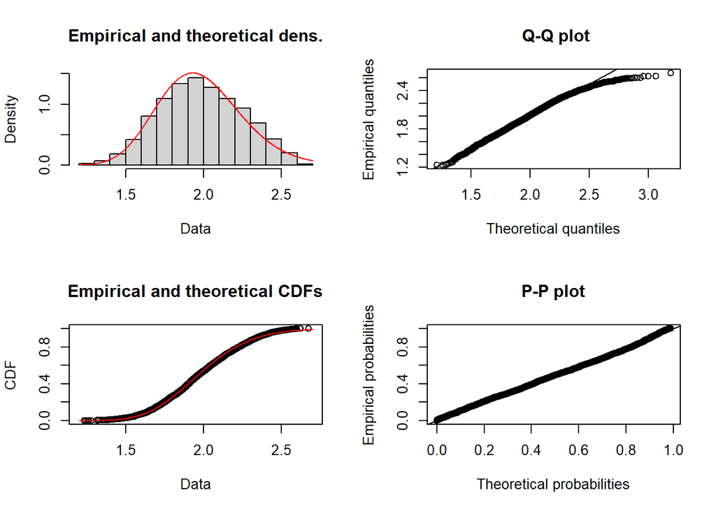

```r
#plot it
plot(fit_log2)
```

```r
#summary of the distribution
gofstat(fit_log2)
```

```
## Goodness-of-fit statistics
##                              1-mle-lnorm
## Kolmogorov-Smirnov statistic  0.02703245
## Cramer-von Mises statistic    0.51551249
## Anderson-Darling statistic    4.14037371
##
## Goodness-of-fit criteria
##                                1-mle-lnorm
## Akaike's Information Criterion    544.1272
## Bayesian Information Criterion    555.9912
```

```r
#fit the transformd response variable to gamma distribution
fit_gamma3 <- fitdist(data_transformed$log_weight,
                   distr = "gamma")
```

for Gamma

## Visualizing the data

trend of mean weight over the year

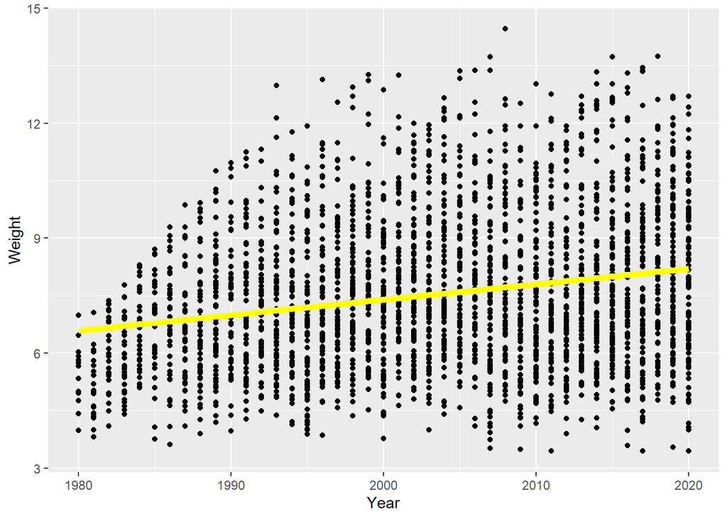

```r
# Create a ggplot with alternative data
ggplot(data = data_transformed, aes(x = year, y = weight) )+
  # Add points to the plot
  geom_point( ) +
  # Add a smoothed line using glm method in red
  geom_smooth(method = "glm", se = FALSE, color = "yellow", size= 2) +
  # Set labels for x and y axes
  labs(x = "Year", y = "Weight")
```

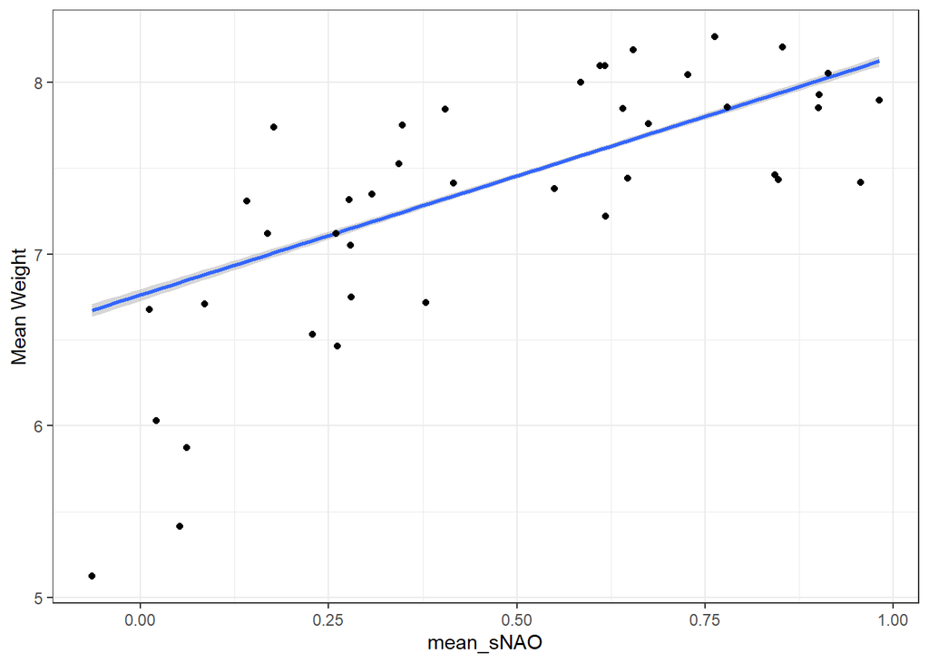

```r
# Create a ggplot with alternative data
ggplot(data_transformed, aes(x = mean_sNAO, y = mean_weight))+
  # Add a smoothed line using glm method with gaussian family
  geom_smooth(method = "glm",
              method.args = list(family = "gaussian"),
              se = TRUE,
              aes())+
  # Add points to the plot with transparency
  geom_point(alpha = 0.5) +
  theme_bw() +
  # Set labels for x and y axes
  labs(x = "mean_sNAO", y = "Mean Weight", color = "Age") +
  # Customize the color legend
  scale_color_discrete(name = "Age")
```

The mean_weight of the Sheep’s steeply increase with respect to mean_sNAO, illustrates the positive increase in the mean_sNAO value amy have a influence on the weight.

Trend of weight over the year with site as factor

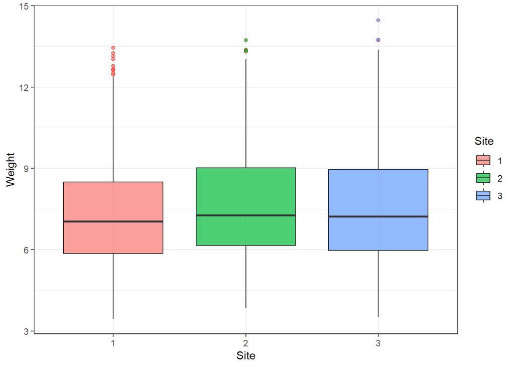

```r
ggplot(alternative, aes(x = as.factor(site), y = weight, fill = as.factor(site))) +
  # Add a box plot
  geom_boxplot(alpha = 0.7, outlier.color = "red", outlier.shape = 21) +
  # Set the theme to a white background
  theme_bw() +
  # Set labels for x and y axes
  labs(x = "Site", y = "Weight", fill = "Site") +
  # Customize the fill legend
  scale_fill_discrete(name = "Site")
```

The median weight in the box plot seem to have, close values.

Trend of weight with sex using factors affecting weight

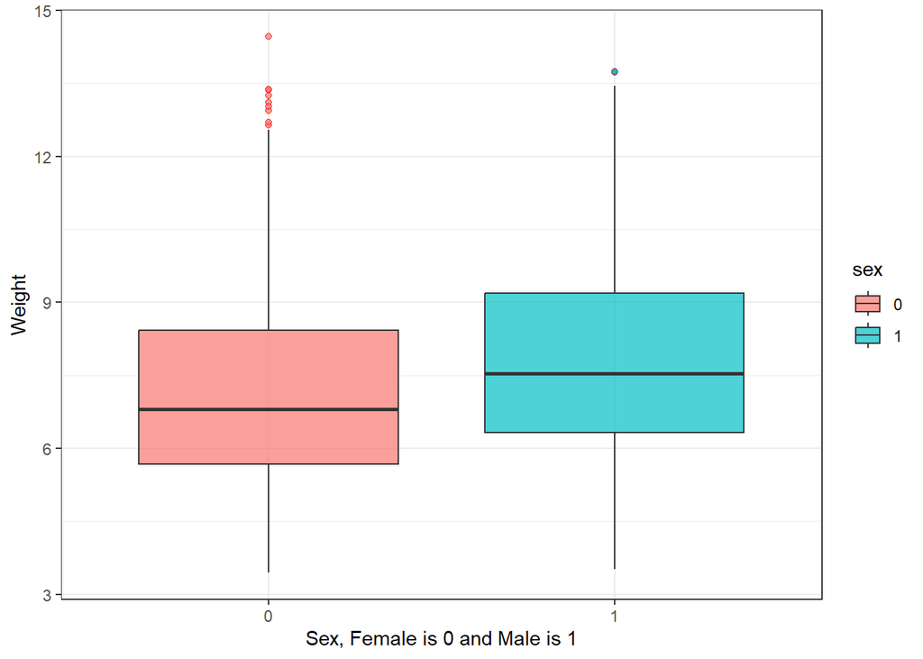

```r
ggplot(alternative, aes(x = as.factor(sex), y = weight, fill = as.factor(sex))) +
  # Add a box plot
  geom_boxplot(alpha = 0.7, outlier.color = "red", outlier.shape = 21) +
  # Set the theme to a white background
  theme_bw() +
  # Set labels for x and y axes
  labs(x = "Sex, Female is 0 and Male is 1", y = "Weight", fill = "sex") +
  # Customize the fill legend
  scale_fill_discrete(name = "sex")
```

Trend of weight with using babies as factors affecting weight

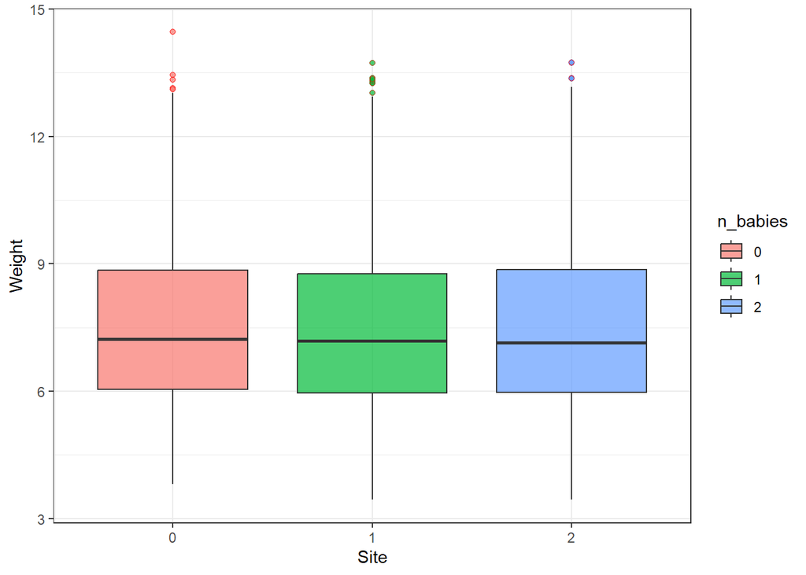

```r
ggplot(alternative, aes(x = as.factor(n_babies), y = weight, fill = as.factor(n_babies))) +
  # Add a box plot
  geom_boxplot(alpha = 0.7, outlier.color = "red", outlier.shape = 21) +
  # Set the theme to a white background
  theme_bw() +
  # Set labels for x and y axes
  labs(x = "Site", y = "Weight", fill = "n_babies") +
  # Customize the fill legend
  scale_fill_discrete(name = "n_babies")
```

The boxplot of weight against the number of babies , the median seem to be almost similar.

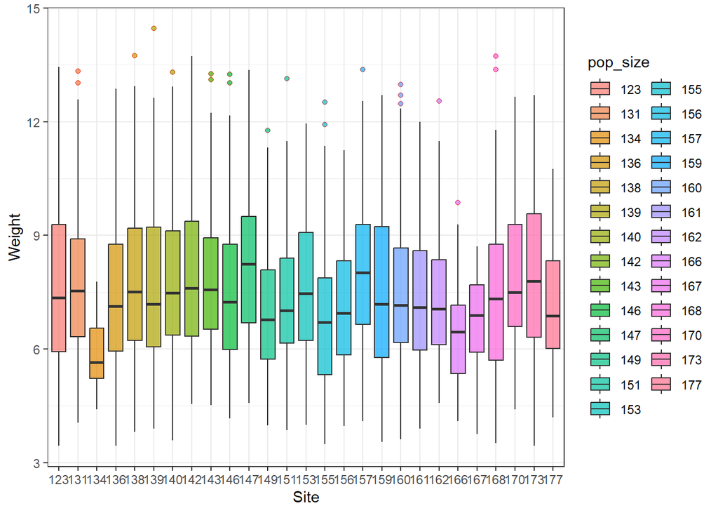

```r
ggplot(alternative, aes(x = as.factor(pop_size), y = weight, fill = as.factor(pop_size))) +
  # Add a box plot
  geom_boxplot(alpha = 0.7, outlier.color = "red", outlier.shape = 21) +
  # Set the theme to a white background
  theme_bw() +
  # Set labels for x and y axes
  labs(x = "Site", y = "Weight", fill = "pop_size") +
  # Customize the fill legend
  scale_fill_discrete(name = "pop_size")
```

The boxplot shows that weight distribution varies across population sizes, with differing medians and variability. Outliers are present, but no clear trend links weight to population size.

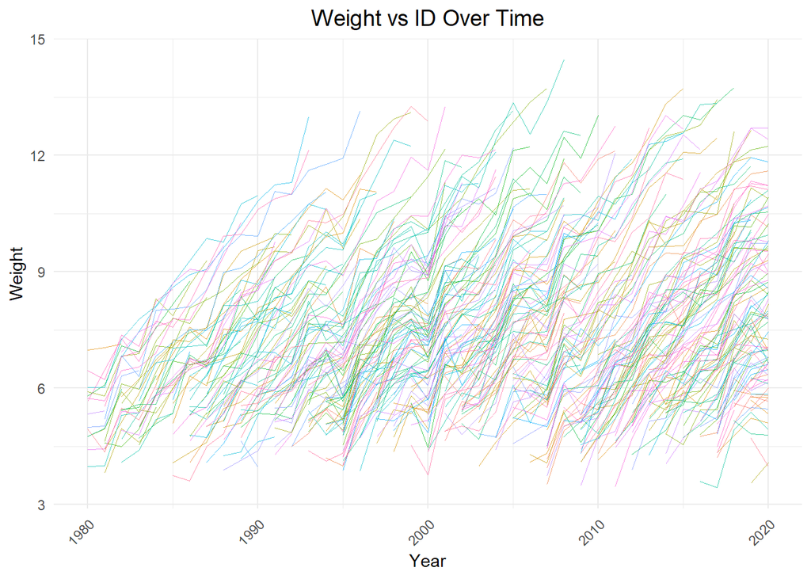

```r
library(ggplot2)

ggplot(data_transformed, aes(x = year, y = weight, group_by(ID), color = as.factor(ID))) +
  geom_line(alpha = 0.7, size = 0.04) +  # Adds semi-transparent lines for smoother visualization
  labs(
    title = "Weight vs ID Over Time",
    x = "Year",
    y = "Weight",
    color = "Individual ID"
  ) +
  theme_minimal() +
  theme(
    plot.title = element_text(hjust = 0.5, size = 14),
    axis.text.x = element_text(angle = 45, hjust = 1),
    legend.position = "none"  # Hides the legend for cleaner visualization
  )
```

This graph represents the individual sheep weight over the year: 1.Overall Trend: There is a general upward trend in weight over the years. Most lines slope upwards, indicating that weights for the individuals increased on average from 1980 to 2020.

2.Individual Variation: The plot shows significant variation between individuals. Some lines are steeper, suggesting faster weight increases, while others are relatively flat, indicating stable weights. Some lines might decrease slightly, representing individuals whose weights declined over time.

Plots imply random effect of factors

## Fitting of Model

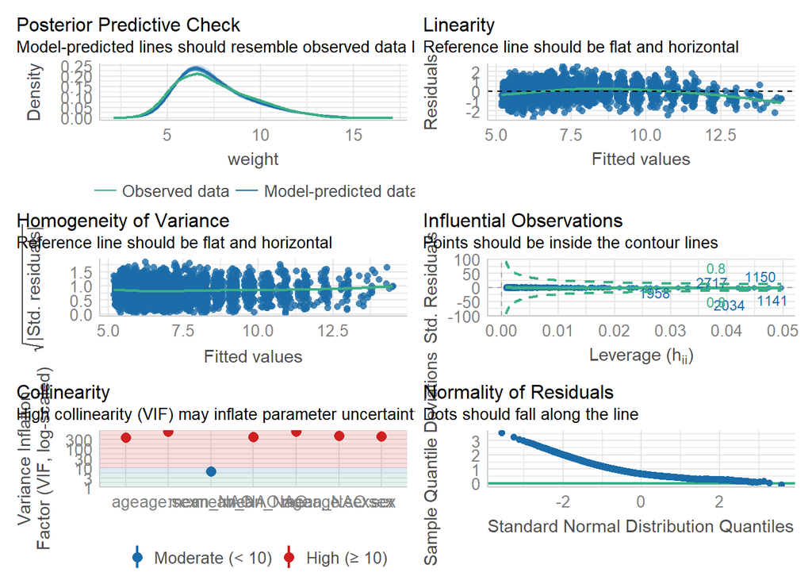

```r
#fitting the model
model <- glm(weight ~mean_NAO+age+sex+mean_NAO:age+age:sex+sex:mean_NAO+mean_NAO:age:sex,
             data = merged_sheep_data,
             family = gaussian(link="log") )
#asses the model
check_model(model)
```

```r
#summary
summary(model)
```

```
##
## Call:
## glm(formula = weight ~ mean_NAO + age + sex + mean_NAO:age +
##     age:sex + sex:mean_NAO + mean_NAO:age:sex, family = gaussian(link = "log"),
##     data = merged_sheep_data)
##
## Coefficients:
##                    Estimate Std. Error t value Pr(>|t|)
## (Intercept)        1.504136   0.060530  24.849  < 2e-16 ***
## mean_NAO           0.195988   0.067742   2.893  0.00384 **
## age                0.068847   0.008685   7.927 3.22e-15 ***
## sex1               0.206915   0.081339   2.544  0.01102 *
## mean_NAO:age      -0.011030   0.009566  -1.153  0.24901
## age:sex1          -0.020993   0.011593  -1.811  0.07027 .
## mean_NAO:sex1     -0.127269   0.091440  -1.392  0.16408
## mean_NAO:age:sex1  0.019675   0.012825   1.534  0.12511
## ---
## Signif. codes:  0 '***' 0.001 '**' 0.01 '*' 0.05 '.' 0.1 ' ' 1
##
## (Dispersion parameter for gaussian family taken to be 0.6076587)
##
##     Null deviance: 11267.5  on 2784  degrees of freedom
## Residual deviance:  1687.5  on 2777  degrees of freedom
## AIC: 6526.1
##
## Number of Fisher Scoring iterations: 4
```

Normality of residuals doesn’t fit the model

### Fitting model for fixed effects and random effects(ID:each indiviuals birth weight differs)

```r
#fit a random effect model
model2 <- glmmTMB(weight~age+mean_NAO+sex+mean_NAO:age+age:sex+sex:mean_NAO+age:mean_NAO:sex+
                    (1|ID),
                  data= alternative,
                   family = lognormal(link = "log")
                  )

#trying to obtain the Rsquared value to know about the variance of fixed and random effects
r.squaredGLMM(model2)
```

```
##             R2m       R2c
## [1,] 0.09600575 0.1122376
```

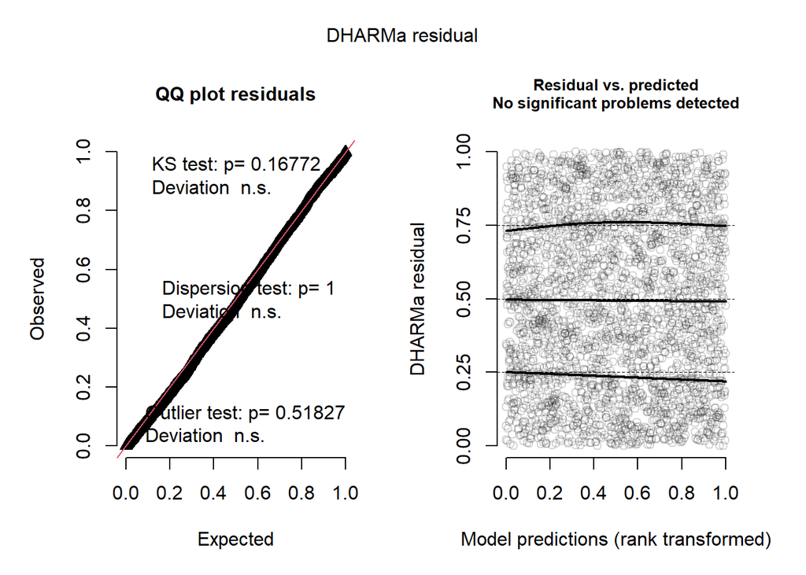

```r
#stimulate residual from the model
m_mod2 <- simulateResiduals(model2, n = 1000)

#plot out the residuals
plot(m_mod2,quantreg=TRUE)
```

[figure not shown]

```
##
##  DHARMa nonparametric dispersion test via sd of residuals fitted vs.
##  simulated
##
## data:  simulationOutput
## dispersion = 1, p-value = 1
## alternative hypothesis: two.sided
```

```r
#To check the dispersion of the data
testDispersion(model2,
               plot=TRUE)
```

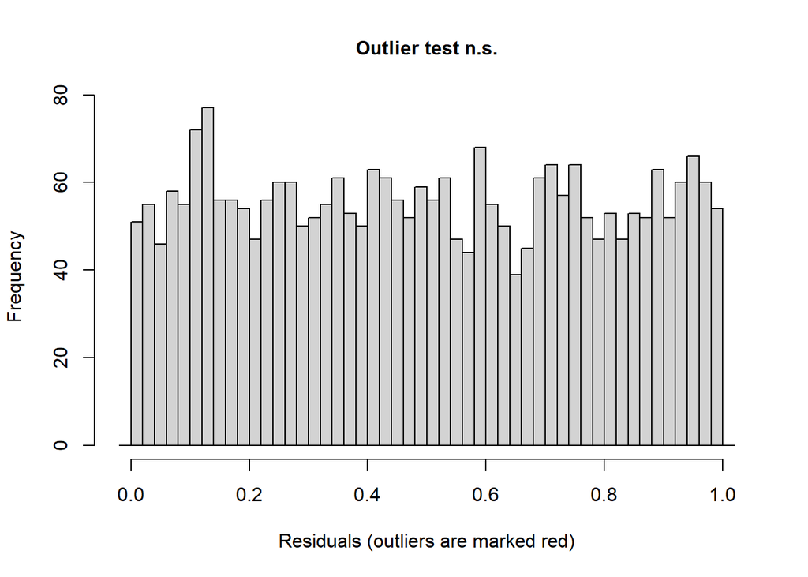

```
##
##  DHARMa outlier test based on exact binomial test with approximate
##  expectations
##
## data:  model2
## outliers at both margin(s) = 21, observations = 2785, p-value = 0.915
## alternative hypothesis: true probability of success is not equal to 0.007968127
## 95 percent confidence interval:
##  0.004673506 0.011503313
## sample estimates:
## frequency of outliers (expected: 0.00796812749003984 )
##                                            0.007540395
```

```r
#To check the outliers of the data
testOutliers(model2,
             plot = TRUE)
```

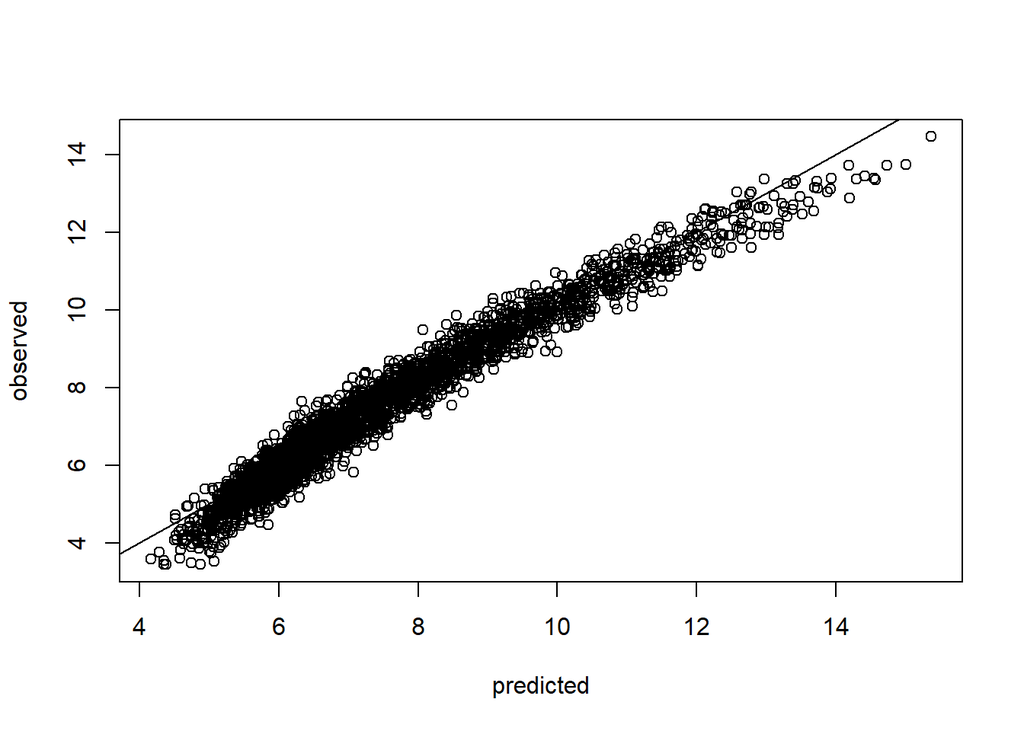

```r
#add the predicted values from the model
predicted_values_0 <- predict(model2, type = "response")

#to plot predicted and observed values of model
fit_data_0 <- data.frame("predicted" = predicted_values_0,
                       "observed" = alternative$weight)
#plot it
plot(fit_data_0)
abline(0,1)
```

Summary indicates that the variance of random effect is really small, so try it with gaussian family

```r
#look at the model2 summary
summary(model2)
```

```
##  Family: lognormal  ( log )
## Formula:
## weight ~ age + mean_NAO + sex + mean_NAO:age + age:sex + sex:mean_NAO +
##     age:mean_NAO:sex + (1 | ID)
## Data: alternative
##
##      AIC      BIC   logLik deviance df.resid
##   4530.2   4589.5  -2255.1   4510.2     2775
##
## Random effects:
##
## Conditional model:
##  Groups Name        Variance Std.Dev.
##  ID     (Intercept) 0.008352 0.09139
## Number of obs: 2785, groups:  ID, 404
##
## Dispersion parameter for lognormal family (): 0.457
##
## Conditional model:
##                    Estimate Std. Error z value Pr(>|z|)
## (Intercept)        1.560237   0.048331   32.28  < 2e-16 ***
## age                0.074181   0.005651   13.13  < 2e-16 ***
## mean_NAO           0.117841   0.053880    2.19  0.02873 *
## sex1               0.029368   0.064725    0.45  0.65002
## age:mean_NAO      -0.016751   0.006237   -2.69  0.00724 **
## age:sex1          -0.003892   0.007604   -0.51  0.60870
## mean_NAO:sex1      0.081028   0.072449    1.12  0.26339
## age:mean_NAO:sex1 -0.001045   0.008446   -0.12  0.90154
## ---
## Signif. codes:  0 '***' 0.001 '**' 0.01 '*' 0.05 '.' 0.1 ' ' 1
```

In model3 the variance is big enough to be considered as a random effect

```r
#fit a random effect model
model3 <- glmmTMB(weight~age+mean_NAO+sex+mean_NAO:age+age:sex+sex:mean_NAO+age:mean_NAO:sex+
                    (1|ID),
                  data= alternative,
                   family = gaussian(link = "identity")
                  )
```

```r
#look at the model summary
summary(model3)
```

```
##  Family: gaussian  ( identity )
## Formula:
## weight ~ age + mean_NAO + sex + mean_NAO:age + age:sex + sex:mean_NAO +
##     age:mean_NAO:sex + (1 | ID)
## Data: alternative
##
##      AIC      BIC   logLik deviance df.resid
##   3554.0   3613.3  -1767.0   3534.0     2775
##
## Random effects:
##
## Conditional model:
##  Groups   Name        Variance Std.Dev.
##  ID       (Intercept) 0.4041   0.6357
##  Residual             0.1376   0.3709
## Number of obs: 2785, groups:  ID, 404
##
## Dispersion estimate for gaussian family (sigma^2): 0.138
##
## Conditional model:
##                   Estimate Std. Error z value Pr(>|z|)
## (Intercept)        5.23311    0.27719  18.879  < 2e-16 ***
## age                0.35722    0.03883   9.198  < 2e-16 ***
## mean_NAO          -0.23944    0.30900  -0.775  0.43840
## sex1               0.27906    0.38579   0.723  0.46947
## age:mean_NAO       0.13084    0.04305   3.040  0.00237 **
## age:sex1           0.04309    0.05344   0.806  0.42008
## mean_NAO:sex1      0.30764    0.43245   0.711  0.47684
## age:mean_NAO:sex1 -0.04856    0.05954  -0.816  0.41473
## ---
## Signif. codes:  0 '***' 0.001 '**' 0.01 '*' 0.05 '.' 0.1 ' ' 1
```

```r
#trying to obtain the Rsquared value to know about the variance of fixed and random effects
r.squaredGLMM(model3)
```

```
##            R2m       R2c
## [1,] 0.8629564 0.9651937
```

Model fits the data

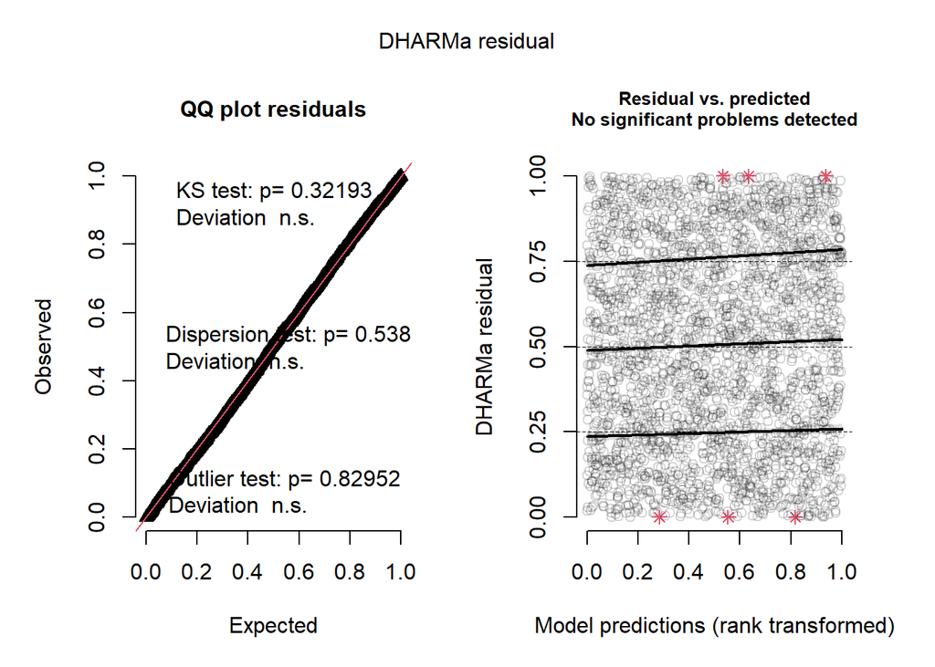

omit “sex” to see if has any effect on model

```r
#fit a random effect model ID with age,mean_sNAO adn babies as the fixed effects
model7 <- glmmTMB(weight~age+mean_sNAO+age:mean_sNAO+
                    (1|ID),
                   data = alternative,
                   family = gaussian(link = "identity")
                  )
```

```r
#look at the model summary
summary(model7)
```

```
##  Family: gaussian  ( identity )
## Formula:          weight ~ age + mean_sNAO + age:mean_sNAO + (1 | ID)
## Data: alternative
##
##      AIC      BIC   logLik deviance df.resid
##   3596.5   3632.1  -1792.2   3584.5     2779
##
## Random effects:
##
## Conditional model:
##  Groups   Name        Variance Std.Dev.
##  ID       (Intercept) 0.4805   0.6932
##  Residual             0.1367   0.3698
## Number of obs: 2785, groups:  ID, 404
##
## Dispersion estimate for gaussian family (sigma^2): 0.137
##
## Conditional model:
##               Estimate Std. Error z value Pr(>|z|)
## (Intercept)   5.214647   0.050182  103.91  < 2e-16 ***
## age           0.454910   0.005426   83.84  < 2e-16 ***
## mean_sNAO     0.176794   0.068382    2.59  0.00973 **
## age:mean_sNAO 0.026242   0.008247    3.18  0.00146 **
## ---
## Signif. codes:  0 '***' 0.001 '**' 0.01 '*' 0.05 '.' 0.1 ' ' 1
```

```r
#trying to obtain the Rsquared value to know about the variance of fixed and random effects
r.squaredGLMM(model7)
```

```
##            R2m       R2c
## [1,] 0.8416946 0.9649299
```

```r
#stimulate residual from the model
m_mod7 <- simulateResiduals(model7, n = 1000)
```

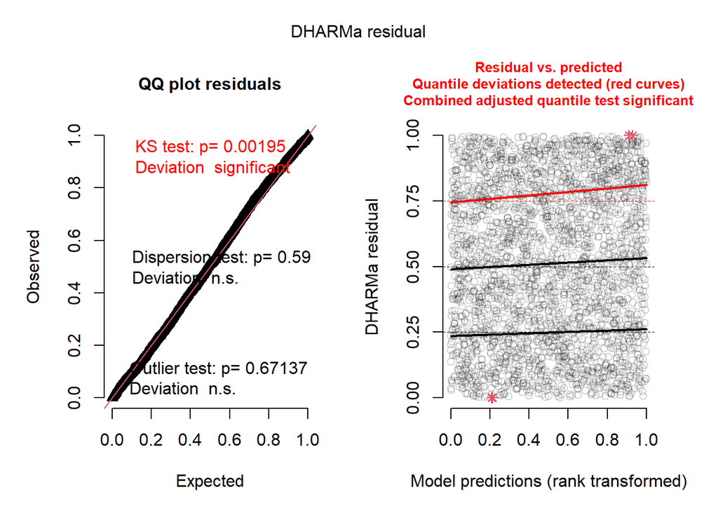

```r
#plot out the residuals
plot(m_mod7,quantreg=TRUE)
```

mean_sNAO modeled as fixed effect instead of mean_NAO

```r
#for mean_sNAO with age and sex as fixed effects and ID as random effect

#fit a random effect model
model4 <- glmmTMB(weight~mean_sNAO+age+sex+mean_sNAO:age+age:sex+sex:mean_sNAO+age:mean_sNAO:sex+
                    (1|ID),
                  data= alternative,
                   family = gaussian(link = "identity")
                  )
```

```r
#look at the model summary
summary(model4)
```

```
##  Family: gaussian  ( identity )
## Formula:
## weight ~ mean_sNAO + age + sex + mean_sNAO:age + age:sex + sex:mean_sNAO +
##     age:mean_sNAO:sex + (1 | ID)
## Data: alternative
##
##      AIC      BIC   logLik deviance df.resid
##   3537.9   3597.2  -1758.9   3517.9     2775
##
## Random effects:
##
## Conditional model:
##  Groups   Name        Variance Std.Dev.
##  ID       (Intercept) 0.4045   0.6360
##  Residual             0.1366   0.3696
## Number of obs: 2785, groups:  ID, 404
##
## Dispersion estimate for gaussian family (sigma^2): 0.137
##
## Conditional model:
##                     Estimate Std. Error z value Pr(>|z|)
## (Intercept)         4.944097   0.069308   71.34  < 2e-16 ***
## mean_sNAO           0.157022   0.095729    1.64  0.10095
## age                 0.450718   0.008208   54.91  < 2e-16 ***
## sex1                0.530845   0.095858    5.54 3.06e-08 ***
## mean_sNAO:age       0.033031   0.012164    2.72  0.00662 **
## age:sex1            0.006939   0.010931    0.63  0.52553
## mean_sNAO:sex1      0.047138   0.134567    0.35  0.72612
## mean_sNAO:age:sex1 -0.012197   0.016543   -0.74  0.46095
## ---
## Signif. codes:  0 '***' 0.001 '**' 0.01 '*' 0.05 '.' 0.1 ' ' 1
```

Plot indicates that model4 is significant

```r
#trying to obtain the Rsquared value to know about the variance of fixed and random effects
r.squaredGLMM(model4,eval(FALSE))
```

```
##            R2m       R2c
## [1,] 0.8625068 0.9652831
```

```r
#stimulate residual from the model
m_mod4 <- simulateResiduals(model4, n = 1000)
```

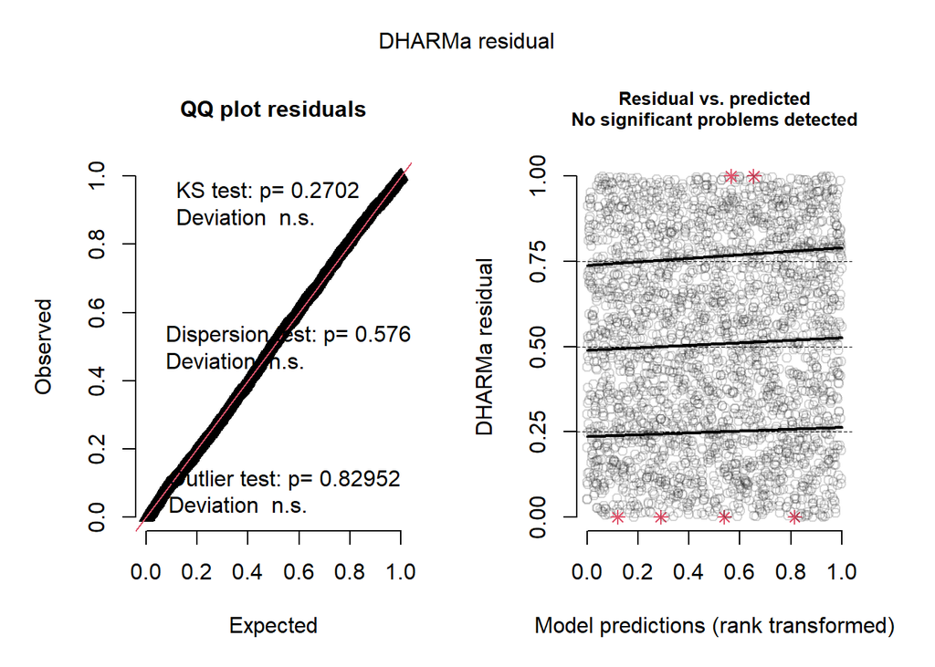

```r
#plot out the residuals
plot(m_mod4,quantreg=TRUE)
```

```r
AIC_model_3 <- AIC(model3)
AIC_model_4 <- AIC(model4)
AIC_model_7 <- AIC(model7)
```

From the AIC value we can go forward with model4 as smaller value indicates as better fit and model7 is anyway rejected by looking at the qqplot of the model

[output not shown]

## Assessing the model and further exploration

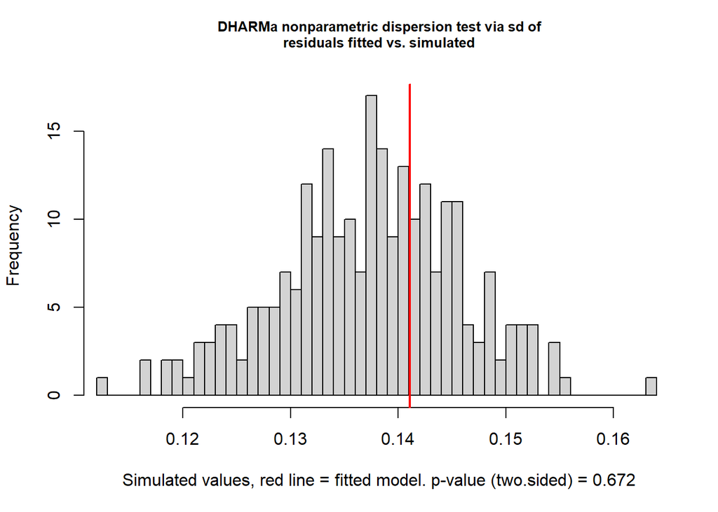

```
##
##  DHARMa nonparametric dispersion test via sd of residuals fitted vs.
##  simulated
##
## data:  simulationOutput
## dispersion = 1.0273, p-value = 0.672
## alternative hypothesis: two.sided
```

```r
#To check the dispersion of the data
testDispersion(model4,
               plot=TRUE)
```

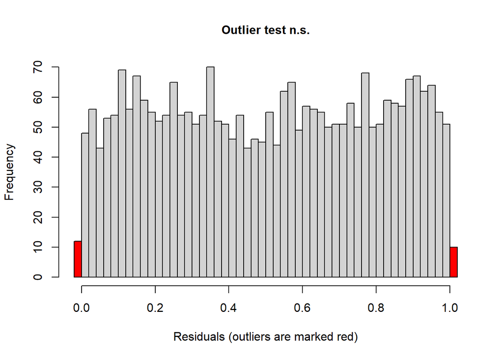

```
##
##  DHARMa outlier test based on exact binomial test with approximate
##  expectations
##
## data:  model4
## outliers at both margin(s) = 22, observations = 2785, p-value = 1
## alternative hypothesis: true probability of success is not equal to 0.007968127
## 95 percent confidence interval:
##  0.00495698 0.01193559
## sample estimates:
## frequency of outliers (expected: 0.00796812749003984 )
##                                            0.007899461
```

```r
#To check the outliers of the data
testOutliers(model4,
             plot = TRUE)
```

Updating the model to fit a better model than the original when AIC is compared

anova summary shows original model is still better than the rest

```
## Data: alternative
## Models:
## model4: weight ~ mean_sNAO + age + sex + mean_sNAO:age + age:sex + sex:mean_sNAO + , zi=~0, disp=~1
## model4:     age:mean_sNAO:sex + (1 | ID), zi=~0, disp=~1
## nb1_mod: weight ~ mean_sNAO + age + sex + mean_sNAO:age + age:sex + sex:mean_sNAO + , zi=~0, disp=~1
## nb1_mod:     age:mean_sNAO:sex + (1 | ID), zi=~1, disp=~1
## log_mod: weight ~ mean_sNAO + age + sex + mean_sNAO:age + age:sex + sex:mean_sNAO + , zi=~age, disp=~1
## log_mod:     age:mean_sNAO:sex + (1 | ID), zi=~0, disp=~1
## Zi_gau_mod1: weight ~ mean_sNAO + age + sex + mean_sNAO:age + age:sex + sex:mean_sNAO + , zi=~0, disp=~1
## Zi_gau_mod1:     age:mean_sNAO:sex + (1 | ID), zi=~0, disp=~1
## Zi_gau_mod: weight ~ mean_sNAO + age + sex + mean_sNAO:age + age:sex + sex:mean_sNAO + , zi=~1, disp=~1
## Zi_gau_mod:     age:mean_sNAO:sex + (1 | ID), zi=~age, disp=~1
##             Df    AIC    BIC  logLik deviance  Chisq Chi Df Pr(>Chisq)
## model4      10 3537.9 3597.2 -1758.9   3517.9
## nb1_mod     10                                            0
## log_mod     10 4498.7 4558.0 -2239.3   4478.7             0
## Zi_gau_mod1 11 3539.9 3605.1 -1758.9   3517.9 960.82      1     <2e-16 ***
## Zi_gau_mod  12 3541.9 3613.0 -1758.9   3517.9   0.00      1          1
## ---
## Signif. codes:  0 '***' 0.001 '**' 0.01 '*' 0.05 '.' 0.1 ' ' 1
```